# ADMM Convex Clustering

Fan Wu

2016-06-14

## TOC

- Convex Clustering as in Chi and Lange (2013)
- Convex Clustering Using Random Effects

## Convex Clustering as in Chi and Lange (2013)

- Try to re-code the original convex clustering problem for multivariate data.
- Current problem:
  - Strange behaviour at the beginning of the path (when $\gamma$ is small);
  - Although the points will finally fused to one, but the whole path deviates a little bit from the corresponding path given by `cvxclustr`.

The left one gives the path by `cvxclustr`; the right one is from my own `R` code.

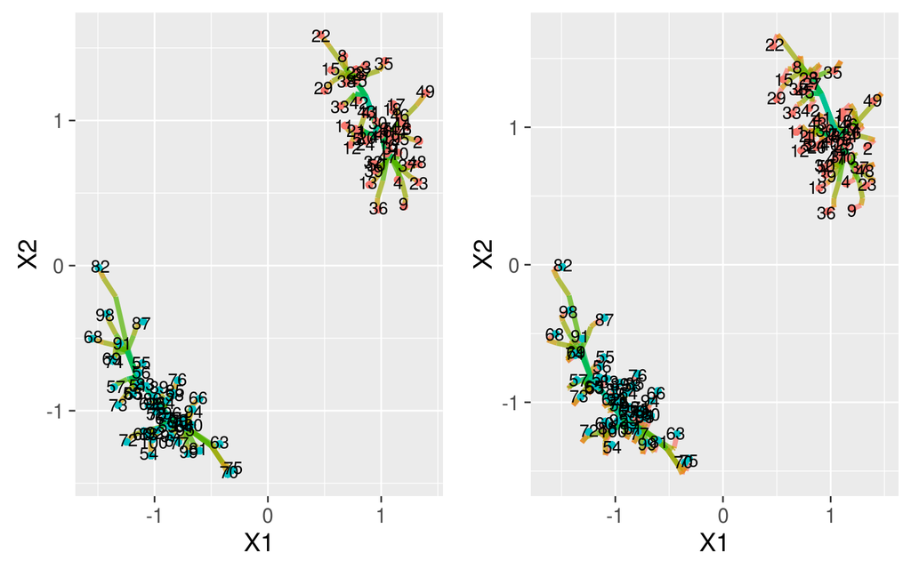

## Convex Clustering Using Random Effects

The code is modified and it can give some “meaningful” clustering, but the strange behaviour when $\gamma$ small retains from the previous section (could still be coding ERRORS).

The following two animations show the clustering of the same dataset using just the random effects (penalizing $\beta$’s) and using the predicted values at 10%, 20%, …, 90% quantiles of pooled sampled times, respectively.

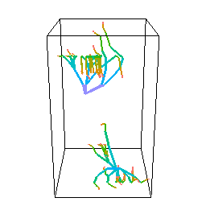

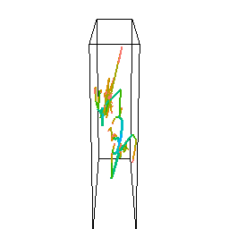

If there is in fact just one cluster, the clustering paths looks like this:

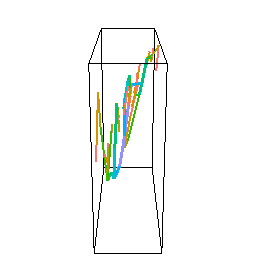